# Model_3

${\huge{Logistic}{~}{Regression}{~}{Modeling}{~}{-}{~}{Grad}{~}{School}{~}{Admission}}$

Multiple linear regression can be modified to model categorical or a count response variable (one type of classification modeling). Given a set of predictors, logistic regression can provide an estimate of the probability of a certain categorical response. There are three types of logistic regression, depending on the nature of the categorial response.

Binary Logistic Regression (the type of regression addressed in the work below) focuses on the probaility of an event occurring (respresented as "yes = 1") or an event not occurring (represented as "no = 0"). The example below will look at the probability of getting into graduate school (Admitted = 1 or Not Admitted = 0) based on grade-point-average (GPA) score, gradute-record-examination score (GRE) and the ranking of the candidate's undergraduate school.

Nominal Logistic Regression is applied when there are three or more response categories possible and there is no order to the response categories. Examples include, vehicle preferred (car, truck, SUV) and subjects picked (math, latin, biology).

Ordinal Logistic Regression is applied when there are three or more response categories and the responses are order ranked. It should be noted that the intervals between rankings do not have to be equal. Choice of levels of hot sauce is an example of an ordinal response.

Learning systems usually assume that the dataset used for learning is balanced (for binary logistic regression, 50% yes's - 50% no's). In the real world there are many examples where the dataset is imbalanced; examples include, cancer diagnosis and telephone fraud detection. For an imbalanced dataset the smaller percentage representing one of the two possible responses is called the minority class; the larger percentage class is called the majority class. A number of different strategies have been developed in order to overcome this class imbalance problem. One of these strategies is called over sampling and Synthetic Minority Over-sampling Technique (SMOTE) has been proven to work well in resolving the class imbalance issue.

# -------------------------------------------------------------------------------

${\huge{Binary}{~}{Logistic}{~}{Regression}{~}{Model}}$

The binary logistic regression model can be represented algebraically as follows.

$${\Large {logit(p)=log{\frac{p}{1 - p}}}={b_0{~}+{~}b_1x_1{~}...{~}+{~}b_{k}x_{k}}} $$

The above model states that the $\underline{natural}$ logrithm of the odds is a linear function of the ${x}$ variables and is called the "log odds". The left-side of the equation is known as the logit transformation of the probability of success, ${p}$.

Manipulating the above equation results in an equation for calculating ${p}$.

$${\Large {p={\frac{exp(b_0{~}+{~}b_1x_1{~}...{~}+{~}b_{k}x_{k})}{1+exp(b_0{~}+{~}b_1x_1{~}...{~}+{~}b_{k}x_{k})}}}} $$

The equations above provide a way of switching between odds and probability, but first a review of odds is in order.

As an example, say the probability of an event is 0.8, then the probability of a non-event will be 1 - 0.8 or 0.2. The odds of success (an event occurring) are defined as the probability of success over the probability of failure, in this case, 0.8/0.2 = 4. Putting it another way, the odds of success are 4 to 1 or a 300% increase in success over failure.

It is important to remember that while probability is limited from 0 to 1, odds, on the other hand, are limited from 0 to infinity, hence the need to tranform odds using the natural log function. For example, a probability of 0.999 is equivalent to odds of 999 and log odds of 6.907. This is important to understand and is related directly to the coefficients of the predictor variables developed by the logistic regression model.

# -------------------------------------------------------------------------------

# Example - Grad School Admission

In this example a school's admissions office would like to be able forecast how three predictors (independent variables), grade-point-average (GPA) score, gradute-record-examamination score (GRE) and the ranking of the candidate's undergraduate school, affect admission (Admitted = 1 or Not Admitted = 0) to their graduate program.

Using Python and data provided by UCLA, a binary logistic regression model will be developed.

Import Python libraries.

```python
import pandas as pd

import statsmodels.api as sm

import pylab as pl

import numpy as np
from sklearn.feature_selection import RFE
from sklearn.model_selection import train_test_split
from sklearn.metrics import roc_auc_score
from sklearn.metrics import roc_curve
from sklearn.linear_model import LogisticRegression
from sklearn import metrics
import matplotlib.pyplot as plt
```

In order to get a feel for the data a number of histograms are plotted below.

One of the first things noted is that the number of no's outnumbers the number of yes's by approximately 2-to-1. This indicates the presence of an imbalanced dataset, 1-to-1 is preferable.

Secondly, the remaining histograms each display scewed normal distributions.

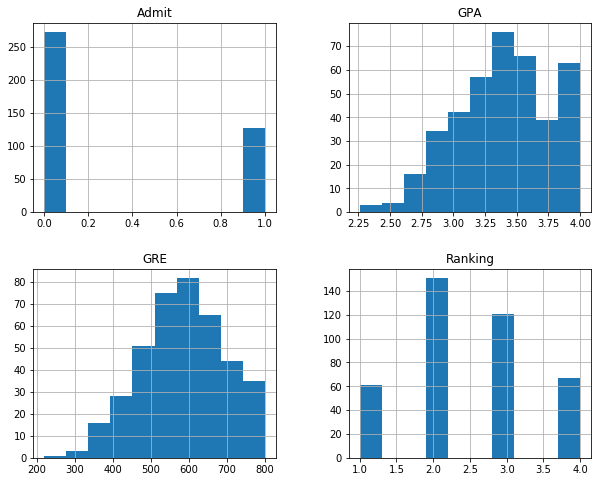

```python
# Read the data

df = pd.read_csv("Grad_Admissions_Data.csv")

# Change the Data Column Titles to be more User Friendly
df.columns = ["Admit", "GRE", "GPA", "Ranking"]
plt.rcParams['figure.figsize'] = 10, 8
df.hist()
pl.show()
```

A more detailed description of the data is provided below.

```python
#Calculate Imbalance Ratio and Percentage of Yes's
count_no = len(df[df['Admit']==0])
count_yes = len(df[df['Admit']==1])
IR = count_no/count_yes
pct_yes = (count_yes/(count_no + count_yes))*100
print("The Imbalance Ratio (IR) is:  %.2f" % IR)
print("The Percent of Yes's is: ", pct_yes)
```

```
The Imbalance Ratio (IR) is:  2.15
The Percent of Yes's is:  31.75
```

```python
# summarize the data

print(df.describe())
```

```
            Admit         GRE         GPA    Ranking
count  400.000000  400.000000  400.000000  400.00000
mean     0.317500  587.700000    3.389900    2.48500
std      0.466087  115.516536    0.380567    0.94446
min      0.000000  220.000000    2.260000    1.00000
25%      0.000000  520.000000    3.130000    2.00000
50%      0.000000  580.000000    3.395000    2.00000
75%      1.000000  660.000000    3.670000    3.00000
max      1.000000  800.000000    4.000000    4.00000
```

Since each undergraduate school's ranking is a value from 1-to-4 (1 being the highest rank) it will be necessary to split the Ranking column into four columns, each column reserved for a specific school ranking. Please see below the results of creating these "dummy" variables.

```python
dummy_ranks = pd.get_dummies(df['Ranking'], prefix='Ranking')

cols_to_keep = ['Admit', 'GRE', 'GPA']

data = df[cols_to_keep].join(dummy_ranks.loc[:, 'Ranking_1':])

print(data)
```

```
     Admit  GRE   GPA  Ranking_1  Ranking_2  Ranking_3  Ranking_4
0        0  380  3.61          0          0          1          0
1        1  660  3.67          0          0          1          0
2        1  800  4.00          1          0          0          0
3        1  640  3.19          0          0          0          1
4        0  520  2.93          0          0          0          1
..     ...  ...   ...        ...        ...        ...        ...
395      0  620  4.00          0          1          0          0
396      0  560  3.04          0          0          1          0
397      0  460  2.63          0          1          0          0
398      0  700  3.65          0          1          0          0
399      0  600  3.89          0          0          1          0

[400 rows x 7 columns]
```

Next, the sklearn logistic regression model is applied to the dataset. Note that the model is first trained using a portion of the dataset and the resulting trained model is used to analyze the remaining unused portion of the dataset; the results of which are displayed using a confusion matrix.

```python
classifier_cols = ['GRE', 'GPA','Ranking_1','Ranking_2','Ranking_3','Ranking_4']
X = data[classifier_cols]
y = data.Admit

# split X and y into training and testing sets
X_train,X_test,y_train,y_test=train_test_split(X,y,test_size=0.25,random_state=0)

#from sklearn.linear_model import LogisticRegression
# instantiate the model (using the default parameters)
logreg = LogisticRegression()

# fit the model with data
logreg.fit(X_train,y_train)


#
y_pred=logreg.predict(X_test)
```

```python
# import the metrics class

cnf_matrix = metrics.confusion_matrix(y_test, y_pred)
print('Computed Confusion Matrix')
print("")
print(cnf_matrix)
```

```
Computed Confusion Matrix

[[60  5]
 [27  8]]
```

The computed confusion matrix is shown above and a heat map of the same matrix is dispplayed below. The confussion matrix helps determine if the model is assigning observations of one class to another class. For example, the confusion matrix indicates that there are 5 false positives, i.e. these students were said to be admitted to grad school, when in fact, they were rejected. Furthermore, there were 27 false negatives, i.e. the model indicated that these students were rejected from grad school, when in fact, these students were actually admitted into grad school.

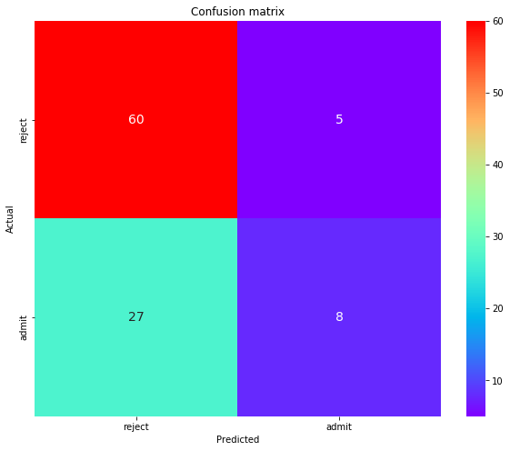

```python
import seaborn as sns

#plotting confusion matrix using heatmap and MATPLOTLIB 3.1.0
sns.heatmap(cnf_matrix, annot=True, annot_kws={'size':14}, cmap="rainbow", xticklabels=['reject','admit'],
            yticklabels=['reject','admit'])
plt.title('Confusion matrix', y=1.1)
plt.ylabel('Actual')
plt.xlabel('Predicted')

plt.show()
```

```python
print("Classification Accuracy:", metrics.accuracy_score(y_test, y_pred))
print("Precision: %.2f" % metrics.precision_score(y_test, y_pred))
print("Recall: %.2f" % metrics.recall_score(y_test, y_pred))
```

```
Classification Accuracy: 0.68
Precision: 0.62
Recall: 0.23
```

As shown above, the model's "Classification Accuracy" or simply, "Accuracy", is 68%. This means that out of all the predictions made, the model is correct 68% of the time.

The "Precision" of the model indicates how often the model is correct when predicting a positive result or, in this example, predicting being admitted into grad school. Using this definition, the model is only correct 62% of the time. In other words, the model may indicate that a student is going to be admitted into grad school, but that is correct only 62% of the time.

For the students in the test dataset that have actually been admitted into grad school, the model can only identify them 23% of the time. This is known as "Recall", which is also known as "Sensitivity" or "True Positive Rate".

"Specificity", which is not shown here, indicates the ability of the model to predict false event or, in this case rejected event, when the student has actually been rejected. Using this definition, the model in this example is correct 92% of the time (60/(60 + 5) * 100).

The Receiver Operator Characteristic Curve (see below) plots true positive rate against false positive rate. The area under the curve (AUC) represents how closely the model predicts the admitted/rejected outcome or, put another way, the probability that the model will rank a randomly chosen positive instance higher than a randomly negative instance. An AUC score of 1 would indicate a perfect predictor, i.e. there is no overlap between true positives and false positives. An AUC score of 0.5, shown as the area under the red diagonal line, indicates that the model did not provide any useful information, similar to random guesses or flipping a coin. This means that the closer the ROC line is to the top left corner of the plot, the better the accuracy of the model.

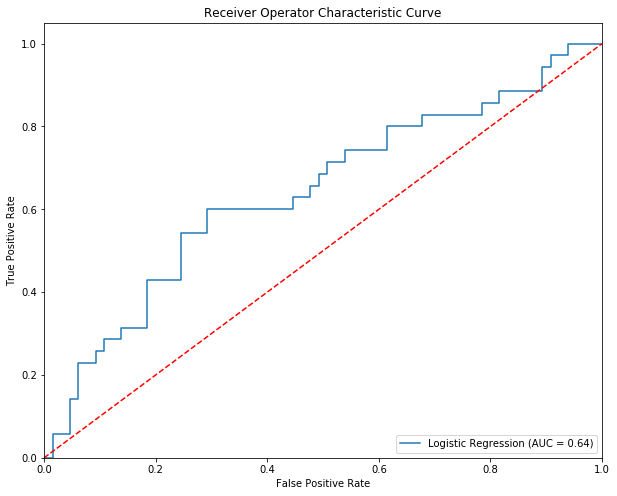

```python
y_pred_proba = logreg.predict_proba(X_test)[::,1]
fpr, tpr, _ = metrics.roc_curve(y_test,  y_pred_proba)
auc = metrics.roc_auc_score(y_test, y_pred_proba)
#plt.plot(fpr,tpr,label="Data, AUC = "+str(auc))
plt.plot(fpr, tpr, label='Logistic Regression (AUC = %0.2f)' % auc)
plt.plot([0, 1], [0, 1],'r--')
plt.xlim([0.0, 1.0])
plt.ylim([0.0, 1.05])
plt.xlabel('False Positive Rate')
plt.ylabel('True Positive Rate')
plt.title('Receiver Operator Characteristic Curve')
plt.legend(loc="lower right")
plt.savefig('Log_ROC')
plt.show()
```

To get a summary table for logistic regression, use the statsmodel Logit function. Note, the whole dataset has been used to give the following results.

```python
logit_model=sm.Logit(y,X)
result=logit_model.fit()
print(result.summary())
```

```
Optimization terminated successfully.
         Current function value: 0.573147
         Iterations 6
                           Logit Regression Results
==============================================================================
Dep. Variable:                  Admit   No. Observations:                  400
Model:                          Logit   Df Residuals:                      394
Method:                           MLE   Df Model:                            5
Date:                Thu, 02 Jan 2020   Pseudo R-squ.:                 0.08292
Time:                        14:19:05   Log-Likelihood:                -229.26
converged:                       True   LL-Null:                       -249.99
Covariance Type:            nonrobust   LLR p-value:                 7.578e-08
==============================================================================
                 coef    std err          z      P>|z|      [0.025      0.975]
------------------------------------------------------------------------------
GRE            0.0023      0.001      2.070      0.038       0.000       0.004
GPA            0.8040      0.332      2.423      0.015       0.154       1.454
Ranking_1     -3.9900      1.140     -3.500      0.000      -6.224      -1.756
Ranking_2     -4.6654      1.109     -4.205      0.000      -6.840      -2.491
Ranking_3     -5.3302      1.150     -4.637      0.000      -7.583      -3.077
Ranking_4     -5.5414      1.138     -4.869      0.000      -7.772      -3.311
==============================================================================
```

The coefficients of the predictor variables require some interpretation.

For example, the GPA coefficient of 0.8040 reveals that, while holding the values of the other predictors fixed, for every unit increase in GPA score the odds of gaining admission to grad school $\underline{increase}$ by 123% (exp(0.8040) = 2.23; odds of 2.23 to 1). Or, if preferred, a probability of 0.69 (where, p = exp(0.8040)/(1 + exp(0.8040))).

Analysis of the ranking coefficients requires a different approach from that used for GRE and GPA. Here rankings are compared to a baseline ranking, in this case, the ranking of the top undergraduate school, which has a coefficient of -3.9900. Graduating from a second ranked undergraduate school, as compared to a top ranked undergraduate school, results in the odds of admission $\underline{decreasing}$ by approximately 49% (exp(-4.6654 - (-3.9900)) - 1 = -0.491). Or, if preferred, a probability of 0.34 (where, p = exp(-0.6754)/(1 + exp(-0.6754))) as compared to a top ranked undergraduate school.